# Analisi Esplorativa - US Chronic Disease

# Conteggio record per Topic e QuestionID

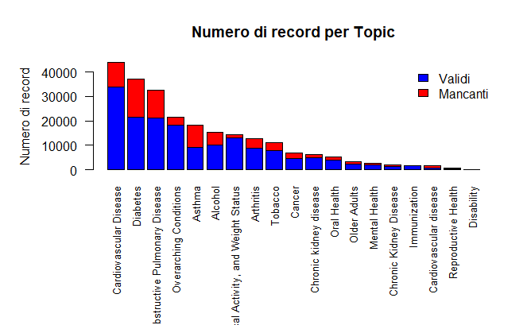

```r
dataset_path <- "u_s_chronic_disease_indicators_cdi.csv"
dataset <- read.csv(dataset_path, stringsAsFactors = FALSE)

is_missing <- is.na(dataset$datavalue) | dataset$datavalue == ""  # true se datavalue è mancante o vuoto

topic_total <- table(dataset$topic)                # conteggio totale per ogni topic
topic_missing <- table(dataset$topic[is_missing])  # conteggio dei record mancanti per topic

topic_missing <- topic_missing[names(topic_total)]   # riordino i mancanti in base ai totali
topic_missing[is.na(topic_missing)] <- 0             # sostituisco i valori mancanti con 0

topic_valid <- topic_total - topic_missing           # calcolo i record validi per topic

counts_matrix <- rbind(Validi = topic_valid, Mancanti = topic_missing)  # creo matrice validi/mancanti

ord <- order(colSums(counts_matrix), decreasing = TRUE) # ordino i topic per numero di record
counts_matrix <- counts_matrix[, ord, drop = FALSE]    # applico l'ordine alla matrice

op <- par(no.readonly = TRUE)              # salvo impostazioni grafiche attuali
on.exit(par(op), add = TRUE)               # ripristino impostazioni a fine esecuzione

par(mar = c(10, 6, 4, 2) + 0.1)            # margini grafico per etichette

barplot(
  counts_matrix,                           # matrice di dati da plottare
  main = "Numero di record per Topic",     # titolo del grafico
  ylab = "Numero di record",               # etichetta asse y
  col = c("blue", "red"),                  # colori per validi e mancanti
  border = "black",                        # bordo delle barre
  las = 2,                                 # ruota etichette asse x
  cex.names = 0.8,                         # dimensione etichette asse x
  mgp = c(4, 1, 0)                         # spostamento etichetta asse y
)

legend("topright", legend = c("Validi", "Mancanti"), # legenda in alto a destra
       fill = c("blue", "red"), bty = "n")           # colori legenda e senza bordo
```

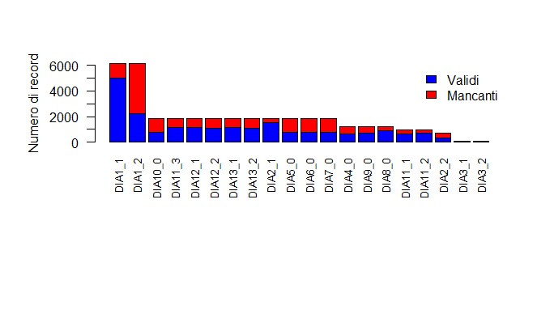

```r
alcohol_data <- subset(dataset, topic == "Diabetes")          # filtro il dataset per topic diabetes

is_missing <- is.na(alcohol_data$datavalue) | alcohol_data$datavalue == ""  # true se datavalue è mancante o vuoto

qid_total   <- table(alcohol_data$questionid)                  # conteggio totale per questionid
qid_missing <- table(alcohol_data$questionid[is_missing])      # conteggio mancanti per questionid

qid_missing <- qid_missing[names(qid_total)]                   # riordino i mancanti in base ai totali
qid_missing[is.na(qid_missing)] <- 0                           # sostituisco i valori mancanti con 0

qid_valid <- qid_total - qid_missing                           # calcolo i record validi per questionid

counts_matrix <- rbind(Validi = qid_valid, Mancanti = qid_missing)  # creo matrice validi/mancanti

ord <- order(colSums(counts_matrix), decreasing = TRUE)        # ordino questionid per numero di record
counts_matrix <- counts_matrix[, ord, drop = FALSE]            # applico l'ordine alla matrice

op <- par(no.readonly = TRUE)                                  # salvo impostazioni grafiche attuali
on.exit(par(op), add = TRUE)                                   # ripristino impostazioni a fine esecuzione

par(mar = c(12, 6, 4, 2) + 0.1)                                # margini più grandi per etichette lunghe

barplot(
  counts_matrix,                                               # matrice di dati da plottare
  main = "",                                                   # titolo vuoto
  ylab = "Numero di record",                                   # etichetta asse y
  col = c("blue", "red"),                                      # colori per validi e mancanti
  border = "black",                                            # bordo delle barre
  las = 2,                                                     # ruota etichette asse x
  cex.names = 0.8,                                             # dimensione etichette asse x
  mgp = c(3.5, 1, 0)                                           # spostamento etichetta asse y
)

legend("topright", legend = c("Validi", "Mancanti"),           # legenda in alto a destra
       fill = c("blue", "red"), bty = "n")                     # colori legenda e senza bordo
```

# Conteggio record Topic per anno di acquisizione

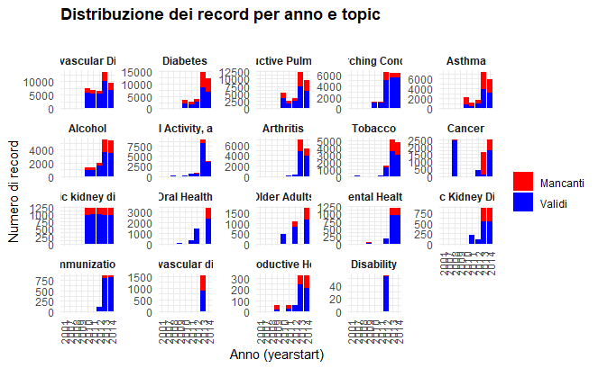

```r
library(dplyr)
library(ggplot2)

dataset_path <- "u_s_chronic_disease_indicators_cdi.csv"
df <- read.csv(dataset_path, stringsAsFactors = FALSE)

names(df) <- tolower(names(df))                            # uniforma i nomi delle colonne in minuscolo

df <- df %>%                                               # modifica dataframe
  mutate(
    status = ifelse(is.na(datavalue) | datavalue == "", "Mancanti", "Validi"), # aggiunge colonna status
    yearstart = as.factor(as.integer(yearstart))           # converte yearstart in fattore ordinato
  )

agg <- df %>%                                              # crea aggregazione
  group_by(topic, yearstart, status) %>%                   # raggruppa per topic, anno e status
  summarise(n = n(), .groups = "drop")                     # conta numero di record

topic_order <- agg %>%                                     # calcola ordine dei topic
  group_by(topic) %>%                                      # raggruppa per topic
  summarise(total = sum(n), .groups = "drop") %>%          # somma record totali
  arrange(desc(total)) %>%                                 # ordina in modo decrescente
  pull(topic)                                              # estrae solo i nomi dei topic

agg$topic <- factor(agg$topic, levels = topic_order)       # applica ordine ai topic nel dataframe

p <- ggplot(agg, aes(x = yearstart, y = n, fill = status)) + # crea grafico ggplot
  geom_col() +                                             # barre verticali
  facet_wrap(~ topic, scales = "free_y") +                 # facet per topic con scale indipendenti
  labs(                                                    # etichette e titoli
    title = "Distribuzione dei record per anno e topic",
    subtitle = "",
    x = "Anno (yearstart)",
    y = "Numero di record",
    fill = NULL
  ) +
  scale_fill_manual(values = c("Validi" = "blue", "Mancanti" = "red")) + # colori personalizzati
  theme_minimal() +                                        # tema minimale
  theme(                                                   # personalizzazioni grafiche
    axis.text.x = element_text(angle = 90, vjust = 0.5, hjust = 1), # ruota etichette x
    strip.text = element_text(face = "bold"),              # testo facet in grassetto
    plot.title = element_text(face = "bold")               # titolo in grassetto
  )

print(p)                                                   # stampa il grafico
```

# DataValueType per ogni QuestionID

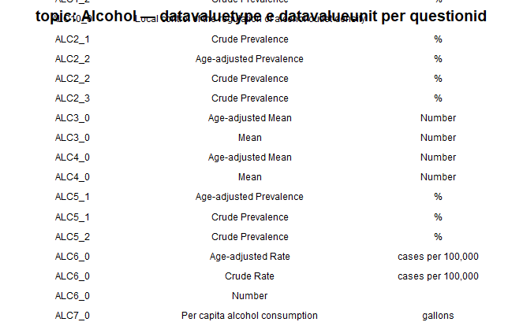

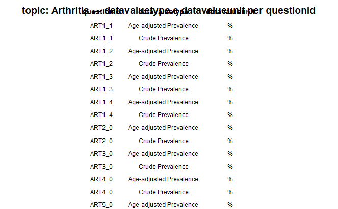

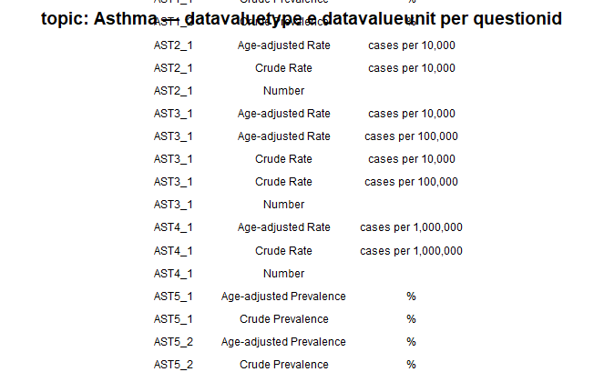

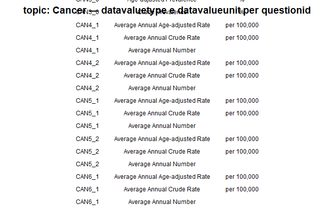

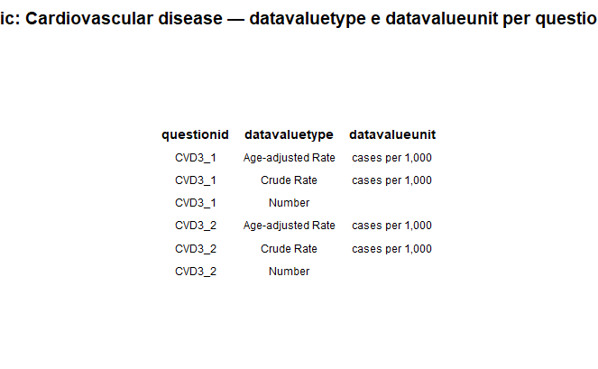

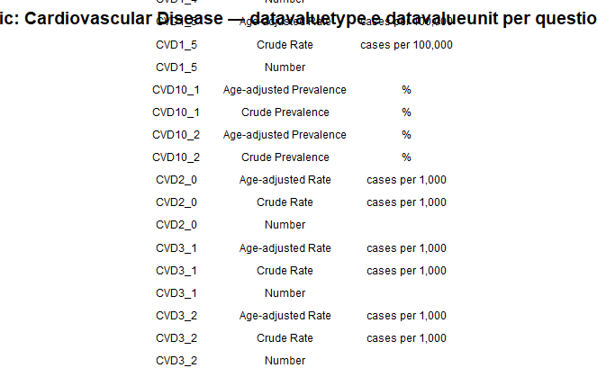

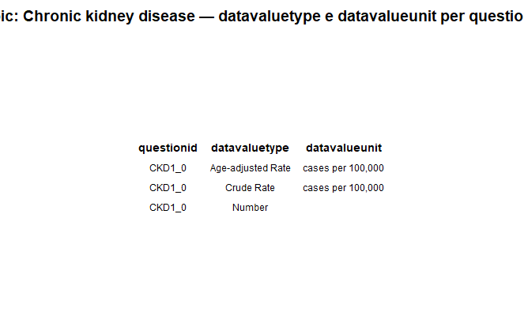

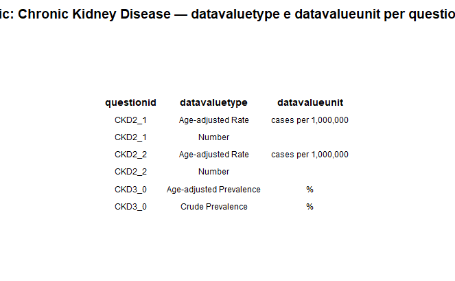

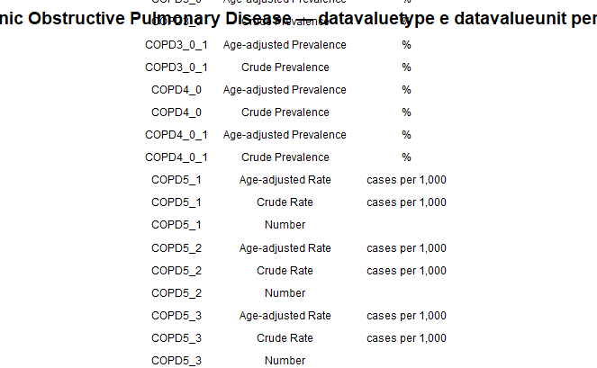

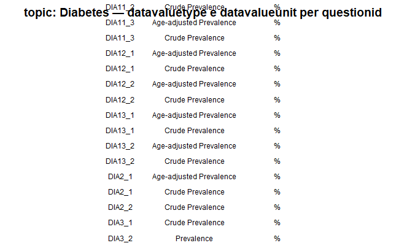

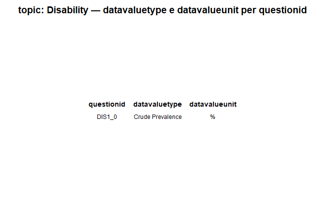

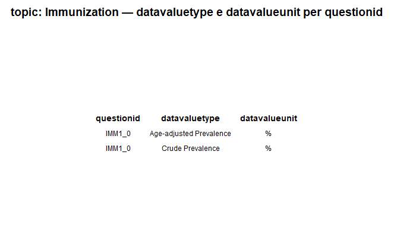

[7 more figures not shown]

```r
library(gridExtra)

dataset_path <- "u_s_chronic_disease_indicators_cdi.csv"
MAX_ROWS_PER_BLOCK <- 200                                      # numero massimo di righe per tabella
SHOW_TOPICS <- NULL                                           # elenco di topic da mostrare o NULL per tutti
OUTPUT_DIR <- "tabelle_topic"                                 # cartella di output per le immagini
IMG_EXT <- "png"                                              # estensione immagine di output
WIDTH <- 1600                                                 # larghezza immagine in pixel
HEIGHT <- 1000                                                # altezza immagine in pixel
DPI <- 150                                                    # risoluzione di stampa per dispositivi compatibili

slugify <- function(x) {                                      # funzione per creare slug dai nomi
  x <- tolower(gsub("[^a-z0-9]+", "-", x))                    # sostituisce tutto tranne lettere/numeri con trattini
  gsub("(^-|-$)", "", x)                                      # rimuove trattini iniziali/finali
}

if (!dir.exists(OUTPUT_DIR)) dir.create(OUTPUT_DIR, TRUE)     # crea la cartella di output se non esiste

df <- read.csv(dataset_path, stringsAsFactors = FALSE, check.names = FALSE)  # carica il csv senza alterare i nomi
names(df) <- tolower(names(df))                                # porta tutti i nomi colonna in minuscolo

req_cols <- c("topic", "questionid", "datavaluetype", "datavalueunit")  # colonne richieste
miss <- setdiff(req_cols, names(df))                           # individua colonne mancanti
if (length(miss) > 0) stop(paste("mancano colonne:", paste(miss, collapse = ", ")))  # interrompe se mancano

dvunit <- df[["datavalueunit"]]                                # copia la colonna datavalueunit
dvunit[is.na(dvunit)] <- ""                                    # sostituisce NA con stringa vuota
df_clean <- unique(data.frame(                                 # crea tabella pulita e unica
  topic = df[["topic"]],
  questionid = df[["questionid"]],
  datavaluetype = df[["datavaluetype"]],
  datavalueunit = dvunit,
  stringsAsFactors = FALSE
))
ord <- with(df_clean, order(topic, questionid, datavaluetype, datavalueunit))  # calcola ordine righe
df_clean <- df_clean[ord, , drop = FALSE]                      # riordina il dataframe

topics <- sort(unique(df_clean$topic))                         # lista ordinata dei topic
if (!is.null(SHOW_TOPICS)) topics <- intersect(topics, SHOW_TOPICS)  # filtra i topic se richiesto

make_table_grob <- function(title_text, df_block) {            # funzione per costruire il grob della tabella con titolo
  tg <- tableGrob(                                             # crea la tabella grafica
    df_block,
    rows = NULL,
    theme = ttheme_minimal(
      core = list(fg_params = list(cex = 0.75, fontface = 1)), # stile celle
      colhead = list(fg_params = list(cex = 0.85, fontface = 2)) # stile header
    )
  )
  title_grob <- grid::textGrob(title_text, gp = grid::gpar(fontface = "bold", cex = 1.2))  # grob del titolo
  gridExtra::arrangeGrob(                                   # impagina titolo + tabella in colonna
    title_grob, tg,
    ncol = 1,
    heights = grid::unit.c(grid::grobHeight(title_grob) + grid::unit(6, "mm"), grid::unit(1, "null"))
  )
}

for (tp in topics) {                                          # ciclo sui topic
  tab <- df_clean[df_clean$topic == tp, c("questionid", "datavaluetype", "datavalueunit"), drop = FALSE]  # estrae le colonne

  if (nrow(tab) == 0) {                                       # se non ci sono righe per il topic
    msg <- sprintf("nessuna combinazione per topic: %s", tp)  # messaggio informativo
    grob <- make_table_grob(msg, data.frame(messaggio = msg)) # costruisce grob con messaggio

    grid::grid.newpage(); grid::grid.draw(grob)               # mostra nel notebook

    out_path <- file.path(OUTPUT_DIR, paste0("topic-", slugify(tp), ".", IMG_EXT))  # path di output
    if (IMG_EXT == "png") {                                   # salva come png
      png(out_path, width = WIDTH, height = HEIGHT, res = DPI); grid::grid.draw(grob); dev.off()
    } else {                                                  # salva come jpeg
      jpeg(out_path, width = WIDTH, height = HEIGHT, quality = 95); grid::grid.draw(grob); dev.off()
    }
    next                                                      # passa al prossimo topic
  }

  idx <- ceiling(seq_len(nrow(tab)) / MAX_ROWS_PER_BLOCK)     # indice per suddividere in blocchi
  blocks <- split(tab, idx)                                   # lista di blocchi di righe

  for (i in seq_along(blocks)) {                              # ciclo sui blocchi
    title <- if (length(blocks) == 1) {                       # titolo se singolo blocco
      sprintf("topic: %s — datavaluetype e datavalueunit per questionid", tp)
    } else {                                                  # titolo se più blocchi
      sprintf("topic: %s — datavaluetype e datavalueunit per questionid (parte %d/%d)", tp, i, length(blocks))
    }
    grob <- make_table_grob(title, blocks[[i]])               # crea il grob per il blocco

    grid::grid.newpage(); grid::grid.draw(grob)               # mostra nel notebook

    suff <- if (length(blocks) == 1) "" else sprintf("-part-%02d", i)  # suffisso file per parti multiple
    out_path <- file.path(OUTPUT_DIR, paste0("topic-", slugify(tp), suff, ".", IMG_EXT))  # path di output
    if (IMG_EXT == "png") {
      png(out_path, width = WIDTH, height = HEIGHT, res = DPI); grid::grid.draw(grob); dev.off()
    } else {
      jpeg(out_path, width = WIDTH, height = HEIGHT, quality = 95); grid::grid.draw(grob); dev.off()
    }
  }
}
```

# Visualizzazione entry StratificationCategory

```r
library(DT)

dataset <- "u_s_chronic_disease_indicators_cdi.csv"
df <- read.csv(dataset, stringsAsFactors = FALSE)
names(df) <- tolower(names(df))                               # uniforma i nomi delle colonne in minuscolo

# df <- dplyr::filter(df, topic == "Alcohol")                 # filtro opzionale per un topic specifico

result <- df %>%                                              # inizio pipeline dplyr (richiede dplyr)
  group_by(questionid, stratificationcategory1, stratification1) %>%  # raggruppa per id domanda e stratificazioni
  summarise(Num_Entry = n(), .groups = "drop") %>%            # conta le righe per gruppo
  rename(
    QuestionID = questionid,                                  # rinomina colonna questionid
    Stratification_Category = stratificationcategory1,        # rinomina colonna stratificationcategory1
    Stratification = stratification1                          # rinomina colonna stratification1
  ) %>%
  arrange(QuestionID, Stratification_Category, Stratification) # ordina le righe per leggibilità

datatable(                                                     # crea tabella interattiva
  result,                                                      # dati da mostrare
  rownames = FALSE,                                            # nasconde i rownames
  options = list(pageLength = 25, autoWidth = TRUE),           # paginazione e larghezza automatica
  filter = "top",                                              # filtro in alto
  class = "display compact nowrap"                             # classi css per stile compatto
)
```

| QuestionID | Stratification_Category | Stratification | Num_Entry |
| --- | --- | --- | --- |
| ALC10_0 | Overall | Overall | 55 |
| ALC1_1 | Overall | Overall | 51 |
| ALC1_2 | Overall | Overall | 55 |
| ALC2_1 | Overall | Overall | 55 |
| ALC2_2 | Gender | Female | 220 |
| ALC2_2 | Gender | Male | 220 |
| ALC2_2 | Overall | Overall | 330 |
| ALC2_2 | Race/Ethnicity | Black, non-Hispanic | 216 |
| ALC2_2 | Race/Ethnicity | Hispanic | 216 |
| ALC2_2 | Race/Ethnicity | Multiracial, non-Hispanic | 216 |

[output cut: 959 more lines]

```r
NA
```

# Verifica stratification per analisi BIAS

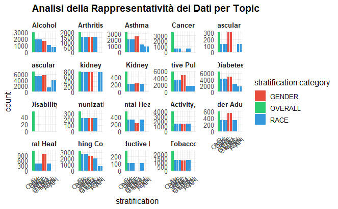

```r
library(ggplot2)                                            # carica libreria per i grafici

df <- df %>%                                                # inizio pulizia dati
  filter(!is.na(stratificationid1), stratificationid1 != "") %>%  # tiene solo righe con stratificazione presente
  mutate(
    stratificationcategoryid1 = toupper(stratificationcategoryid1), # porta la categoria in maiuscolo
    topic = factor(topic)                                   # converte topic in fattore
  )

df <- df %>%                                                # ricalcola ordine etichette x per frequenza
  group_by(topic, stratificationid1) %>%                    # raggruppa per topic e stratificazione
  summarise(n = n(), .groups = "drop") %>%                  # conta le occorrenze
  group_by(topic) %>%                                       # raggruppa per topic
  arrange(topic, desc(n), .by_group = TRUE) %>%             # ordina per frequenza decrescente
  mutate(xlvl = factor(stratificationid1, levels = unique(stratificationid1))) %>% # crea fattore ordinato
  select(topic, stratificationid1, xlvl) %>%                # mantiene solo colonne utili
  right_join(df, by = c("topic", "stratificationid1")) %>%  # riunisce con il df originale
  mutate(stratificationid1 = ifelse(is.na(xlvl), stratificationid1, as.character(xlvl))) %>% # sostituisce con livello ordinato
  mutate(stratificationid1 = factor(stratificationid1, levels = unique(stratificationid1))) %>% # fissa i livelli del fattore
  select(-xlvl)                                             # rimuove colonna temporanea

fill_values <- c(                                           # definisce colori fissi per alcune categorie
  "GENDER"  = "#E74C3C",
  "OVERALL" = "#2ECC71",
  "RACE"    = "#3498DB"
)
unknown_levels <- setdiff(unique(df$stratificationcategoryid1), names(fill_values)) # individua categorie non mappate
if (length(unknown_levels) > 0) {                          # se ci sono categorie extra
  extra_cols <- setNames(rep("#95A5A6", length(unknown_levels)), unknown_levels) # assegna grigio
  fill_values <- c(fill_values, extra_cols)                # unisce ai colori esistenti
}

p <- ggplot(df, aes(x = stratificationid1, fill = stratificationcategoryid1)) + # imposta mapping estetico
  geom_bar(position = position_dodge(width = 0.9)) +        # barre affiancate
  facet_wrap(~ topic, scales = "free_y") +                  # facet per topic con scala y libera
  labs(                                                     # etichette del grafico
    title = "Analisi della Rappresentatività dei Dati per Topic",
    x = "stratification",
    y = "count",
    fill = "stratification category"
  ) +
  scale_fill_manual(values = fill_values, drop = FALSE) +   # applica colori personalizzati
  theme_minimal(base_size = 12) +                           # tema minimale
  theme(
    axis.text.x = element_text(angle = 45, hjust = 1),      # ruota etichette asse x
    strip.text  = element_text(face = "bold"),              # titoli dei pannelli in grassetto
    plot.title  = element_text(face = "bold"),              # titolo in grassetto
    panel.grid.minor = element_blank()                      # rimuove griglia minore
  )

print(p)                                                    # stampa il grafico
```

# Distribuzioni divise per DataValueType

Codice per plottare distribuzioni di frequenza dei valori contenuti in datavalue per ogni tipologia di datavaluetype divisi per questionid/topic.

```r
library(ggplot2)
library(dplyr)

DATASET_PATH <- "u_s_chronic_disease_indicators_cdi.csv"
TOP_N_COMBINATIONS <- NULL                                   # limite opzionale alle combinazioni
MIN_ROWS_PER_COMBO <- 1                                      # righe minime per includere una combinazione
FACET_THRESHOLD <- 16                                        # soglia per decidere facet unico o loop

df <- read.csv(DATASET_PATH, na.strings = c("", "NA", "NULL", "null"), stringsAsFactors = FALSE)  # carica il csv gestendo i na
names(df) <- tolower(names(df))                              # porta i nomi colonna in minuscolo

stopifnot(all(c("questionid","datavaluetype","datavalue") %in% names(df)))  # verifica colonne richieste

df$datavalue <- suppressWarnings(as.numeric(df$datavalue))   # converte datavalue in numerico silenziando warning
df <- df %>% filter(!is.na(datavalue))                       # rimuove righe con datavalue non numerico o mancante

combo_stats <- df %>%                                        # calcola numerosità per combinazione
  count(questionid, datavaluetype, name = "n_rows") %>%      # conta righe per questionid x datavaluetype
  arrange(desc(n_rows)) %>%                                  # ordina per righe decrescenti
  filter(n_rows >= MIN_ROWS_PER_COMBO)                       # filtra combinazioni troppo piccole

if (!is.null(TOP_N_COMBINATIONS)) {                          # se richiesto, limita il numero di combinazioni
  combo_stats <- head(combo_stats, TOP_N_COMBINATIONS)       # prende solo le prime n combinazioni
}

freq_df <- df %>%                                            # prepara frequenze per valore
  semi_join(combo_stats, by = c("questionid","datavaluetype")) %>%  # tiene solo le combo selezionate
  group_by(questionid, datavaluetype, datavalue) %>%         # raggruppa per combo e valore
  summarise(frequency = n(), .groups = "drop") %>%           # conta le occorrenze per valore
  arrange(questionid, datavaluetype, datavalue)              # ordina per leggibilità

if (nrow(freq_df) == 0) {                                    # se non ci sono dati dopo i filtri
  stop("nessun dato disponibile dopo i filtri (controlla MIN_ROWS_PER_COMBO/TOP_N_COMBINATIONS).")  # interrompe con messaggio
}

freq_df <- freq_df %>%                                       # imposta fattori per ordine stabile
  mutate(
    questionid    = factor(questionid, levels = unique(combo_stats$questionid)),   # ordina questionid
    datavaluetype = factor(datavaluetype, levels = unique(combo_stats$datavaluetype)) # ordina datavaluetype
  )

# === calcolo statistiche per ogni combinazione (media, mediana, moda, varianza, sd) ===
stats_df <- df %>%
  semi_join(combo_stats, by = c("questionid","datavaluetype")) %>%
  group_by(questionid, datavaluetype) %>%
  summarise(
    mean   = mean(datavalue, na.rm = TRUE),
    median = median(datavalue, na.rm = TRUE),
    mode   = as.numeric(names(which.max(table(datavalue)))),
    var    = var(datavalue, na.rm = TRUE),
    sd     = sd(datavalue, na.rm = TRUE),
    .groups = "drop"
  ) %>%
  mutate(
    label_mean   = paste0("Media (µ=", round(mean, 2), ")"),
    label_median = paste0("Mediana (med=", round(median, 2), ")"),
    label_mode   = paste0("Moda (mod=", round(mode, 2), ")")
  )

num_combos <- nrow(combo_stats)                               # numero di combinazioni selezionate

if (num_combos <= FACET_THRESHOLD) {                          # caso facet unico se poche combinazioni
  p <- ggplot(freq_df, aes(x = datavalue, y = frequency)) +

    geom_col(fill = "blue", alpha = 0.7, width = 0.9) +

    geom_vline(data = stats_df, aes(xintercept = mean,   color = label_mean),   linetype = "solid",   linewidth = 1) +
    geom_vline(data = stats_df, aes(xintercept = median, color = label_median), linetype = "dashed",  linewidth = 1) +
    geom_vline(data = stats_df, aes(xintercept = mode,   color = label_mode),   linetype = "dotdash", linewidth = 1) +

    geom_text(data = stats_df, aes(x = mean,   y = Inf, label = paste0("µ=", round(mean, 2))),   vjust = -0.5, color = "red",   size = 3, fontface = "bold") +
    geom_text(data = stats_df, aes(x = median, y = Inf, label = paste0("med=", round(median, 2))), vjust = -0.5, color = "black", size = 3, fontface = "bold") +
    geom_text(data = stats_df, aes(x = mode,   y = Inf, label = paste0("mod=", round(mode, 2))),   vjust = -0.5, color = "green", size = 3, fontface = "bold") +

    scale_color_manual(
      name = "Statistiche",
      values = c("red", "black", "green"),
      breaks = c(stats_df$label_mean[1], stats_df$label_median[1], stats_df$label_mode[1]),
      labels = c(stats_df$label_mean[1], stats_df$label_median[1], stats_df$label_mode[1])
    ) +

    facet_grid(datavaluetype ~ questionid, scales = "free_y") +
    labs(
      title = "distribuzione di frequenza di datavalue per questionid × datavaluetype",
      x = "datavalue",
      y = "frequenza",
      caption = "Legenda: µ = media | med = mediana | mod = moda | var = varianza | sd = deviazione standard"
    ) +
    theme_minimal(base_size = 11) +
    theme(
      strip.text = element_text(face = "bold"),
      plot.title = element_text(face = "bold"),
      panel.grid.minor = element_blank()
    )

  print(p)

} else {  # === caso loop per combinazioni singole ===
  combos <- combo_stats %>% select(questionid, datavaluetype)

  for (i in seq_len(nrow(combos))) {
    qi  <- combos$questionid[i]
    dvt <- combos$datavaluetype[i]

    sub <- freq_df %>% filter(questionid == qi, datavaluetype == dvt)
    sub_stats <- stats_df %>% filter(questionid == qi, datavaluetype == dvt)

    if (nrow(sub) == 0) next

    p <- ggplot(sub, aes(x = datavalue, y = frequency)) +
      geom_col(fill = "blue", alpha = 0.7, width = 0.9) +

      geom_vline(data = sub_stats, aes(xintercept = mean,   color = label_mean),   linetype = "solid",   linewidth = 1) +
      geom_vline(data = sub_stats, aes(xintercept = median, color = label_median), linetype = "dashed",  linewidth = 1) +
      geom_vline(data = sub_stats, aes(xintercept = mode,   color = label_mode),   linetype = "dotdash", linewidth = 1) +

      geom_text(data = sub_stats, aes(x = mean,   y = Inf, label = paste0("µ=", round(mean, 2))),   vjust = -0.5, color = "red",   size = 3, fontface = "bold") +
      geom_text(data = sub_stats, aes(x = median, y = Inf, label = paste0("med=", round(median, 2))), vjust = -0.5, color = "black", size = 3, fontface = "bold") +
      geom_text(data = sub_stats, aes(x = mode,   y = Inf, label = paste0("mod=", round(mode, 2))),   vjust = -0.5, color = "green", size = 3, fontface = "bold") +

      scale_color_manual(
        name = "Statistiche",
        values = c("red", "black", "green"),
        breaks = c(sub_stats$label_mean, sub_stats$label_median, sub_stats$label_mode),
        labels = c(sub_stats$label_mean, sub_stats$label_median, sub_stats$label_mode)
      ) +

      labs(
        title = paste("distribuzione di frequenza —", qi, "—", dvt),
        x = "datavalue",
        y = "frequenza",
        caption = paste0("Var = ", round(sub_stats$var, 3), " | SD = ", round(sub_stats$sd, 3))
      ) +
      theme_minimal(base_size = 12) +
      theme(
        plot.title = element_text(face = "bold"),
        panel.grid.minor = element_blank()
      )

    print(p)
  }
}
```

[output not shown]

# Moda dati qualitativi

```r
library(DT)
library(stringr)

dataset_path <- "u_s_chronic_disease_indicators_cdi.csv"
df <- read.csv(dataset_path, na.strings = c("", "NA", "NULL", "null"), stringsAsFactors = FALSE)
names(df) <- tolower(names(df))                               # uniforma nomi colonne in minuscolo

keep_types <- c("LclCntrlAlc", "CommHstLiab", "YesNo")        # tipi da mantenere
df_filtered <- df %>%                                         # inizio filtro
  filter(datavaluetypeid %in% keep_types)                     # tiene solo righe con tipo tra i selezionati

df_filtered <- df_filtered %>%                                # cast esplicito
  mutate(datavalue = as.character(datavalue))                 # tratta datavalue come qualitativo

mode_stats <- function(x) {                                   # funzione per calcolare la/e moda/e
  x <- x[!is.na(x)]                                           # rimuove na
  if (length(x) == 0) {                                       # se vettore vuoto
    return(list(mode_value = NA_character_, mode_count = NA_integer_, n = 0))  # ritorna valori assenti
  }
  tab <- sort(table(x), decreasing = TRUE)                    # frequenze ordinate
  maxc <- as.integer(tab[1])                                  # frequenza massima
  modes <- names(tab[tab == maxc])                            # tutte le modalità con maxc
  list(
    mode_value = paste(modes, collapse = " | "),              # concatena le mode con separatore
    mode_count = maxc,                                        # conta della moda
    n = length(x)                                             # numero totale di osservazioni
  )
}

modes_df <- df_filtered %>%                                   # calcola moda per combinazione
  group_by(topic, questionid, datavaluetypeid) %>%            # raggruppa per topic, domanda e tipo
  summarise(                                                  # compone lista con statistiche
    stats = list(mode_stats(datavalue)),
    .groups = "drop"
  ) %>%
  mutate(                                                     # estrae campi dalla lista
    mode_value = vapply(stats, `[[`, character(1), "mode_value"),  # valore/i della moda
    mode_count = vapply(stats, `[[`, integer(1),   "mode_count"),  # frequenza della moda
    n          = vapply(stats, `[[`, integer(1),   "n"),           # numerosità del gruppo
    mode_pct   = ifelse(n > 0, round(100 * mode_count / n, 1), NA_real_) # percentuale della moda
  ) %>%
  select(topic, questionid, datavaluetypeid, mode_value, mode_count, mode_pct, n) %>%  # colonne finali
  arrange(topic, questionid, datavaluetypeid)                 # ordina per leggibilità

datatable(                                                     # mostra tabella interattiva
  modes_df,                                                    # dati da visualizzare
  rownames = FALSE,                                            # niente rownames
  filter = "top",                                              # filtri in alto
  options = list(pageLength = 25, autoWidth = TRUE),           # paginazione e larghezza automatica
  colnames = c(                                                # intestazioni colonne
    "Topic", "QuestionID", "DataValueTypeID",
    "Moda (valori)", "Frequenza moda", "% moda", "N osservazioni"
  ),
  class = "display compact nowrap"                             # stile compatto e no wrap
)
```

| Topic | QuestionID | DataValueTypeID | Moda (valori) | Frequenza moda | % moda | N osservazioni |
| --- | --- | --- | --- | --- | --- | --- |
| Alcohol | ALC10_0 | LclCntrlAlc | Category 3 - State had exclusive state alcohol retail licensing but with local zoning authority | 16 | 32 | 50 |
| Alcohol | ALC9_0 | CommHstLiab | Category 2 - State had commercial host liability with major limitations | 24 | 47.1 | 51 |
| Nutrition, Physical Activity, and Weight Status | NPAW14_0 | YesNo | No | 33 | 64.7 | 51 |
| Nutrition, Physical Activity, and Weight Status | NPAW19_0 | YesNo | No | 44 | 86.3 | 51 |
| Nutrition, Physical Activity, and Weight Status | NPAW22_0 | YesNo | No | 49 | 96.1 | 51 |
| Nutrition, Physical Activity, and Weight Status | NPAW9_1 | YesNo | No | 41 | 80.4 | 51 |
| Nutrition, Physical Activity, and Weight Status | NPAW9_2 | YesNo | No | 47 | 92.2 | 51 |
| Tobacco | TOB4_0 | YesNo | Yes | 27 | 52.9 | 51 |
| Tobacco | TOB5_0 | YesNo | Yes | 36 | 70.6 | 51 |
| Tobacco | TOB7_0 | YesNo | No | 49 | 96.1 | 51 |

# Analisi distribuzione di frequenza (Test del $\chi^2$)

Data la distribuzione di frequenze dei valori osservati per il fenomeno *ALC3_0* con *datavaluetype* = “Mean” ci chiediamo:

**H0:** il fenomeno segue una distribuzione normale  
**H1:** il fenomeno non segue un distribuzione normale  
Verifichiamo:

```r
library(dplyr)

DATASET_PATH <- "u_s_chronic_disease_indicators_cdi.csv"

vals <- read.csv(DATASET_PATH, na.strings = c("", "NA", "NULL", "null"), stringsAsFactors = FALSE) %>%
  rename_all(tolower) %>%   # rende i nomi colonna minuscoli
  filter(
    questionid == "ALC3_0",
    tolower(datavaluetype) == "mean"
  ) %>%
  mutate(datavalue = suppressWarnings(as.numeric(datavalue))) %>%
  filter(!is.na(datavalue)) %>%
  pull(datavalue)   # estrae solo la colonna come vettore


vals   # stampa il vettore
```

```
  [1] 5.0 5.0 4.2 4.5 5.4 5.1 4.7 6.3 4.4 4.7 3.9 4.3 3.4 3.9 4.4 4.9 3.3 4.6 4.0 5.0 4.0 4.4 3.0 4.0 3.9 4.6 4.8 4.3 3.3 4.6 3.6 5.0 5.0 5.3 4.9 4.7 4.3 3.5 4.7 3.7 3.8 5.7 7.5
 [44] 2.5 5.4 3.7 4.6 4.0 2.8 4.4 3.5 3.2 4.0 4.5 3.0 4.3 3.6 3.1 3.6 4.2 4.0 3.5 4.3 2.5 4.4 5.0 3.3 4.6 3.9 3.8 3.8 4.2 3.0 3.9 2.6 4.2 4.9 2.9 4.3 4.5 3.8 4.0 3.7 3.6 3.8 3.4
 [87] 3.7 4.0 4.8 2.8 3.7 4.7 3.8 4.1 4.0 4.4 4.3 3.7 4.2 2.9 3.7 3.2 4.4 4.7 5.3 3.6 4.9 3.8 3.8 4.7 5.2 3.8 5.3 4.3 3.6 5.1 4.9 4.6 5.4 2.8 4.9 4.2 4.5 3.7 4.2 5.3 4.4 5.8 6.7
[130] 3.3 5.0 7.2 5.0 5.2 4.2 4.3 4.1 4.8 5.2 3.9 5.1 5.0 3.9 5.3 4.9 5.1 4.2 4.9 4.7 4.9 4.8 5.1 4.2 4.8 3.2 4.3 4.5 5.1 3.2 4.5 3.9 3.9 4.2 3.3 4.0 4.6 5.4 3.3 4.5 4.4 4.2 4.7
[173] 3.3 4.6 4.1 2.9 4.1 4.3 4.7 3.5 4.7 3.4 4.5 5.2 3.2 4.5 5.1 4.8 4.5 3.8 4.4 4.6 4.6 4.3 4.0 4.3 3.1 4.0 3.2 4.3 4.9 3.0 4.4 3.8 4.3 3.9 4.7 3.4 5.6 6.6 5.4 5.0 5.9 3.2 5.0
[216] 6.3 5.3 4.2 4.5 3.6 4.5 2.9 4.8 5.4 3.5 4.6 5.0 5.0 4.2 5.0 2.9 4.3 3.0 5.0 4.2 4.9 3.0 4.3 5.7 3.1 3.6 4.4 3.7 3.8 3.5 3.7 4.2 2.6 4.2 4.8 3.2 4.1 4.4 4.1 4.5 5.1 3.4 4.4
[259] 4.4 5.1 3.2 4.4 4.2 4.5 5.1 3.6 4.5 5.6 4.4 5.1 3.3 4.5 3.9 3.8 4.9 4.3 3.6 4.1 2.9 3.6 3.3 5.0 4.2 4.6 3.4 4.2 2.6 4.0 3.6 4.9 5.4 3.8 5.0 2.8 4.4 5.2 2.9 3.7 4.1 4.4 4.2
[302] 4.5 3.4 4.3 3.0 5.1 5.4 4.5 4.5 6.2 4.8 4.6 5.4 3.1 4.8 3.4 4.4 3.4 4.1 3.5 4.5 3.7 4.2 2.6 4.0 3.0 3.3 4.3 4.5 3.9 4.4 4.6 2.5 4.4 4.2 5.1 2.7 3.8 3.9 3.9 4.4 2.7 3.8 3.9
[345] 3.9 4.0 4.6 2.8 4.0 3.7 4.2 4.7 3.3 4.1 3.2 4.2 4.0 4.4 3.3 4.0 4.2 4.8 3.3 4.2 4.5 3.7 4.1 3.0 3.8 4.4 3.2 3.5 3.9 3.0 3.8 3.3 2.6 3.7 3.5 4.8 4.8 4.9 4.5 4.8 4.7 4.4 4.8
[388] 3.6 5.1 3.9 3.7 4.3 4.8 5.7 3.1 4.1 4.0 5.1 5.8 3.7 6.1 3.6 3.3 4.6 3.7 3.4 3.0 3.5 3.5 3.1 3.8 4.1 3.2 4.1 3.9 2.8 3.3 4.7 5.5 3.4 4.6 4.9 4.5 5.0 3.7 4.6 3.2 4.3 4.3 4.8
[431] 3.0 4.4 3.5 4.6 3.9 4.5 4.9 3.8 4.3 5.3 3.9 4.6 4.4 5.1 3.2 4.4 4.5 4.8 4.1 4.4 4.4 4.0 4.2 3.5 4.0 4.1 4.6 5.1 3.6 4.5 5.0 4.9 4.2 4.0 4.4 3.1 4.0 4.1 4.4 3.0 4.1 4.0 4.0
[474] 4.4 3.3 4.2 3.2 4.7 5.2 3.8 4.9 3.3 4.0 4.6 5.2 3.3 4.6 4.4 4.6 5.3 3.2 4.7 4.0 4.6 3.9 4.2 3.3 4.0 3.4 4.0 4.6 2.8 3.9 4.2 4.0 5.2 5.8 3.6 5.7 5.0 3.3 3.7 2.6 3.5 4.3 4.5
[517] 3.4 4.9 3.2 4.1 4.4 5.0 3.3 4.5 6.1 4.0 4.6 4.2 4.8 3.3 4.4 4.9 3.3 4.6 5.2 3.3 4.6 4.2 4.6 5.1 3.7 4.7 3.9 3.9 4.3 4.8 3.4 4.5 3.3 4.2 4.7 3.2 4.2 3.6 4.0 4.6 5.0 4.1 4.4
[560] 4.3 4.7 3.7 4.3 3.9 4.0 4.4 3.3 4.1 3.6 4.3 4.6 3.9 4.5 3.6 4.0 4.2 4.1 4.5 3.4 4.1 4.1 4.5 3.5 4.2 4.7 4.1 5.5 6.3 3.3 5.3 5.4 6.0 4.0 5.3 5.2 4.0 4.4 2.9 4.1 5.0 5.4 4.0
[603] 4.7 4.7
```

```r
n <- length(vals)
print("Grandezza campione")
```

```
[1] "Grandezza campione"
```

```r
n
```

```
[1] 604
```

```r
m <- mean(vals)
print("Mean")
```

```
[1] "Mean"
```

```r
m
```

```
[1] 4.211755
```

```r
s <- sd(vals)
print("SD")
```

```
[1] "SD"
```

```r
s
```

```
[1] 0.7583767
```

```r
# utilizzando quantili determiniamo 5 intervalli Ii

a <- numeric(4)
for(i in 1:4)
  a[i]<- qnorm(0.2*i, mean=m, sd=s)

print("Valori intervalli")
```

```
[1] "Valori intervalli"
```

```r
a
```

```
[1] 3.573489 4.019622 4.403888 4.850021
```

$I_1 = (-\infty, +3.573489),\space I_2 = [+3.573489, 4.019622),\space I_3 = [4.019622, 4.403888),\space I_4 = [4.403888, 4.850021),\space I_5 = [4.850021, +\infty)$

Otteniamo così i 5 intervalli, ora visualiziamo le frequenze per ognuno.

```r
r <- 5
nint <- numeric(r)
nint[1] <- length(which(vals<a[1]))
nint[2] <- length(which((vals>=a[1])&(vals<a[2])))
nint[3] <- length(which((vals>=a[2])&(vals<a[3])))
nint[4] <- length(which((vals>=a[3])&(vals<a[4])))
nint[5] <- length(which(vals>=a[4]))

("Frequenze per ogni intervallo")
```

```
[1] "Frequenze per ogni intervallo"
```

```r
nint
```

```
[1] 122 126 133 108 115
```

```r
("Totale osservazioni")
```

```
[1] "Totale osservazioni"
```

```r
sum(nint)
```

```
[1] 604
```

Calcoliamo quindi l’indice $\chi^2$

```r
chi2 <- sum((nint - n*0.2)^2/(n*0.2))
chi2
```

```
[1] 3.102649
```

Poichè il numero di intervalli è r = 5 e k parametri della distribuzione normale, avremo

**gradi di libertà** = r - k - 1 = 2.

Impostiamo il livello di significatività $\alpha = 0.05$

```r
r <- 5
k <- 2
alpha <- 0.05
right <- qchisq(alpha/2, df=r-k-1)
right
```

```
[1] 0.05063562
```

```r
left <- qchisq(1-alpha/2, df=r-k-1)
left
```

```
[1] 7.377759
```

Essendo $\chi^2 = 3.102649$ quindi $0.05063562 < \chi^2 < 7.377759$ non possiamo rifiutare l’ipotesi nulla **H0**.

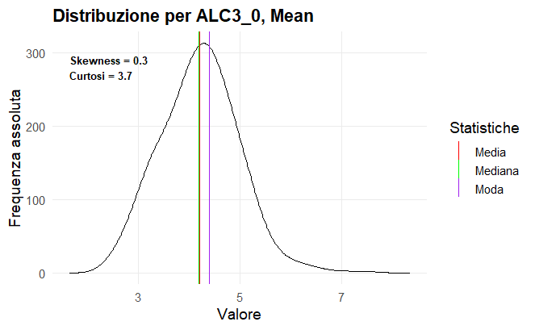

```r
library(ggplot2)
library(dplyr)
library(moments)

# ---- statistiche principali ----
media   <- mean(vals)
mediana <- median(vals)
moda    <- vals %>% table() %>% which.max() %>% names() %>% as.numeric()

# ---- skewness & kurtosis ----
skew_val  <- skewness(vals)
kurt_val  <- kurtosis(vals)

# ---- density calcolata e convertita in frequenza assoluta ----
dens <- density(vals, adjust = 1.5)
dens_df <- data.frame(
  x = dens$x,
  freq_ass = dens$y * length(vals)
)

# ---- plot ----
ggplot(dens_df, aes(x = x, y = freq_ass)) +
  geom_line(size = .7, color = "black") +

  geom_vline(aes(xintercept = media, colour = "Media"), size = .5) +
  geom_vline(aes(xintercept = mediana, colour = "Mediana"), size = .5) +
  geom_vline(aes(xintercept = moda, colour = "Moda"), size = .5) +

  scale_colour_manual(values = c("Media" = "red", "Mediana" = "green", "Moda" = "purple")) +

  annotate(
    "text",
    x = min(dens_df$x),
    y = max(dens_df$freq_ass, na.rm = TRUE) * 0.95,
    label = paste0(
      "Skewness = ", round(skew_val, .5), "\n",
      "Curtosi = ", round(kurt_val, .5)
    ),
    hjust = 0, vjust = 1, size = 3.5, fontface = "bold"
  ) +

  labs(
    title = "Distribuzione per ALC3_0, Mean",
    x = "Valore",
    y = "Frequenza assoluta",
    colour = "Statistiche"
  ) +
  theme_minimal(base_size = 14) +
  theme(
    plot.title = element_text(face = "bold"),
    panel.grid.minor = element_blank()
  )
```

$Mediana \approx_< Media < Moda$

**Leggera asimmetria positiva** (coda leggermente più allungata a destra).

**Moderatamente leptocurtica**, valori concentrati intorno alla media.

# P-value

```r
library(dplyr)

# Caricamento dataset
cdi <- read.csv(
  "u_s_chronic_disease_indicators_cdi.csv",
  stringsAsFactors = FALSE
)

# Filtro e conversione a numerico
diabetes_mortality <- cdi %>%
  filter(
    topic == "Diabetes",
    questionid == "DIA1_1",
    yearstart >= 2010 & yearend <= 2014,
    stratificationcategory1 == "Overall",
    datavaluetype == "Crude Rate"
  ) %>%
  mutate(datavalue = as.numeric(datavalue)) %>%
  filter(!is.na(datavalue)) %>%
  pull(datavalue)

# Controllo rapido
summary(diabetes_mortality)
```

```
   Min. 1st Qu.  Median    Mean 3rd Qu.    Max.
  40.80   72.97   81.95   83.79   95.08  141.80
```

```r
# Parametri del test
mu0 <- 65.8
alpha <- 0.05

# Test di ipotesi monolaterale
test_result <- t.test(
  diabetes_mortality,
  mu = mu0,
  alternative = "greater",
  conf.level = 1 - alpha
)

test_result
```

```
    One Sample t-test

data:  diabetes_mortality
t = 15.337, df = 259, p-value < 2.2e-16
alternative hypothesis: true mean is greater than 65.8
95 percent confidence interval:
 81.85571      Inf
sample estimates:
mean of x
 83.79231
```

### Verifica delle ipotesi sulla mortalità per diabete

L’obiettivo di sanità pubblica **Healthy People 2010** stabilisce come target una mortalità per diabete pari a **65.8 decessi per 100.000 abitanti**, considerando il diabete come causa primaria o contributiva di morte.

Sono stati analizzati i dati relativi alla mortalità per diabete nel periodo **2010–2014**, limitandosi ai valori complessivi e ai **Crude Rate**, al fine di garantire la confrontabilità tra le osservazioni considerate.

È stato quindi costruito un **test di verifica delle ipotesi monolaterale** con livello di significatività α=0.05, formulando le seguenti ipotesi:

H0:μ≤65.8 H1:μ>65.8

dove μ rappresenta la mortalità media per diabete osservata nel campione.

Poiché la deviazione standard della popolazione non è nota, è stato applicato un **t test**. La statistica di test confronta la media campionaria dei tassi di mortalità con il valore di riferimento μ0=65.8

Il test ha restituito una **media campionaria pari a 83.79 decessi per 100.000 abitanti**, con una statistica t=15.337 e un **p value inferiore a** 2.2×10^-16.

Poiché il p value risulta ampiamente inferiore al livello di significatività prefissato, **l’ipotesi nulla viene rifiutata**.

Si conclude pertanto che, nel periodo considerato, la mortalità media per diabete risulta **statisticamente significativa e superiore** al target di sanità pubblica stabilito da Healthy People 2010. Tale conclusione è ulteriormente supportata dall’intervallo di confidenza unilaterale al 95%, il cui estremo inferiore è pari a **81.86**, valore nettamente superiore alla soglia di riferimento di 65.8.

```r
library(dplyr)

# Caricamento dataset
cdi <- read.csv(
  "u_s_chronic_disease_indicators_cdi.csv",
  stringsAsFactors = FALSE
)

# Filtro e conversione a numerico
alcohol_liver_mortality <- cdi %>%
  filter(
    topic == "Alcohol",
    questionid == "ALC6_0",
    yearstart >= 2010 & yearend <= 2014,
    stratificationcategory1 == "Overall",
    datavaluetype == "Age-adjusted Rate"
  ) %>%
  mutate(datavalue = as.numeric(datavalue)) %>%
  filter(!is.na(datavalue)) %>%
  pull(datavalue)

# Controllo rapido
summary(alcohol_liver_mortality)

# Parametri del test
mu0 <- 3.2     # target Healthy People 2010
alpha <- 0.05

# Test di ipotesi monolaterale
test_result <- t.test(
  alcohol_liver_mortality,
  mu = mu0,
  alternative = "greater",
  conf.level = 1 - alpha
)

test_result
```

[output not shown]

### Verifica delle ipotesi sulla mortalità per malattie del fegato correlate all’alcol

L’obiettivo di sanità pubblica **Healthy People 2010** stabiliva come target la riduzione della mortalità per malattie croniche del fegato e cirrosi a **3.2 decessi per 100.000 abitanti**, misurata tramite tasso **age-adjusted**.

Sono stati analizzati i dati relativi alla mortalità per malattie del fegato associate al consumo di alcol (indicatore **ALC6_0**) nel periodo **2010–2014**, limitandosi ai valori complessivi e ai **Age-adjusted Rate**, al fine di garantire la confrontabilità tra le osservazioni considerate.

È stato quindi costruito un **test di verifica delle ipotesi monolaterale** con livello di significatività α=0.05, formulando le seguenti ipotesi:

H0:μ≤3.2 H1:μ>3.2

dove μ rappresenta la mortalità media per malattie del fegato osservata nel campione.

Poiché la deviazione standard della popolazione non è nota, è stato applicato un **t test**. La statistica di test confronta la media campionaria dei tassi di mortalità con il valore di riferimento μ0=3.2